# 1_Pre_Calib_wire_1yech

**Notebook to Calibrate Wires trajectory for DAXM measurements from Fluorescence intensity shadowing**

- load a DAXM scan with visible shadows lines (scan performed on single sample point that produces fluorescence)
- GUI to find a set approached values for the N wires
- Refinement of Calibration parameters

**Section 2**: to start from scratch and select a daxm scan of interest

**Section 3**: GUI to find rather good parameters of the wires trajectory and positions. A .scan file is saved with these parameters in a created analysis directory. By default it is called `init_calib.scan` This section can be skipped

**Section 4**: Calibration procedure, which can be started by loading `init_calib.scan` file.

# -------------------------------------------------------------

Initial version: Robin Freville based on Loic Renversade Code

Major Revision by Clement Ribart 2026

Last Revision by J.-S. Micha June 2026

# IMPORTS AND ENVIRONMENTS

```python
!which python
```

```
/data/bm32/inhouse/SOFT/lauetoolsDEV/bin/python
```

```python
import os, sys, ipympl
print(f'you are using pythn {sys.version}')
if sys.version_info.minor>=8:
    %matplotlib ipympl
    try:
        import ipympl
    except:
        print('You need to install ipympl: pip install ipympl')
else:
    %matplotlib notebook
```

```
you are using pythn 3.12.12 | packaged by conda-forge | (main, Jan 26 2026, 23:51:32) [GCC 14.3.0]
```

```python
sys.executable, sys.version
```

```
('/data/bm32/inhouse/SOFT/lauetoolsDEV/bin/python',
 '3.12.12 | packaged by conda-forge | (main, Jan 26 2026, 23:51:32) [GCC 14.3.0]')
```

```python
import os, time, copy
import itertools
import glob
from pathlib import Path

import matplotlib.pyplot as plt
#----------- global imports -----------

import matplotlib as mpl
import matplotlib.pylab as mplp
import matplotlib.pyplot as plt

import numpy as np

from __future__ import print_function
from ipywidgets import interact, interactive, fixed, interact_manual
import ipywidgets as widgets
```

```python
if 0: # test if we can get some plots (depending on notebook version ... and ipympl needs or not)
    fig_,ax_ = plt.subplots()
    ax_.plot(np.arange(20))
```

```python
# in jupyter-slurm for venv environment only (not conda !!  for this you need to create a ipykernel and)
# LaueToolsCode_Folder = '/data/bm32/inhouse/lauetoolsenv2/lib/python3.12/site-packages'
# sys.path.insert(0,LaueToolsCode_Folder)
# print(sys.path)
# import LaueTools as LT
# print('\ncode from', LT.__file__)
```

```python
import fabio
import pandas as pd
from pathlib import Path
from matplotlib.patches import Polygon
from matplotlib.lines import Line2D
```

```python
#----------- daxm imports -----------
from LaueTools.Daxm.classes.scan import new_scan
from LaueTools.Daxm.classes.source import new_source
#from LaueTools.Daxm.classes.calibration import CalibManager
#from LaueTools.Daxm.classes.reconstruction import SpotReconstructor
from LaueTools.Daxm.classes.scan.point import StaticPointScan, new_scan_dict, PointScan, save_scan_dict
import LaueTools.generaltools as GT
import LaueTools.logfile_reader as iohdf5
import LaueTools.blissdatafolderstructure as blissf
GT.__file__
```

```
loading lauetools_config.json in  /gpfs/jazzy/data/bm32/inhouse/SOFT/lauetoolsDEV/lauetools/LaueTools
No user materials.yaml found. Using default materials.yaml
loading lauetools_config.json in  /gpfs/jazzy/data/bm32/inhouse/SOFT/lauetoolsDEV/lauetools/LaueTools
No user materials.yaml found. Using default materials.yaml
-- WARNING: Missing library libtiff, Please install: pylibtiff if you need open some tiff images. However, Fabio or PIL can do the job!
Using 'cumulative_trapezoid' as 'cumtrapz' (newer SciPy version)
sys.version in source.py 3.12.12 | packaged by conda-forge | (main, Jan 26 2026, 23:51:32) [GCC 14.3.0]
```

```
'/gpfs/jazzy/data/bm32/inhouse/SOFT/lauetoolsDEV/lauetools/LaueTools/generaltools.py'
```

```python
#print(mpl.get_backend())
#sys.version
```

```python
if 0: # test if we can get some plots (depending on notebook version ... and ipympl needs or not)
    fig_,ax_ = plt.subplots()
    ax_.plot(np.arange(20))
```

# SET DAXM SCAN, DETECTOR, USER FOLDER

```python
# example of the way data are organised in folders tree
# sample='Au15_1'
# dataset = '2Dmap_after'
# f'{sample}_{dataset}'
# f'/data/visitor/ma5820/bm32/20240208/RAW_DATA/{sample}/{sample}_{dataset}'

configurations = {
"blc17179": {
        "maindatafolder_RAW_DATA": "/data/visitor/blc17179/bm32/20260617/RAW_DATA/",
        "mainfolder_PROCESSED_DATA": "/data/visitor/blc17179/bm32/20260617/PROCESSED_DATA",
        "CCDType": "EIGER_4MCdTe",
        "Newsample_Name": "BaTiO3",
        "NewDataset_Name": "daxmfluo",
        "Scan_repo_Nb": "0001",
    },
"a321216": {
        "maindatafolder_RAW_DATA": "/data/visitor/a321216/bm32/20251008/RAW_DATA",
        "mainfolder_PROCESSED_DATA": "/data/visitor/a321216/bm32/20251008/PROCESSED_DATA",
        "CCDType": "sCMOS_4M",
        "Newsample_Name": "ech15_R3",
        "Zone": "Z1",
        "NewDataset_Name": "Z1_daxm_dia_combo_Line_1_10umstep",
        "Scan_repo_Nb": "0001",
    },

"blc16918": {
        "maindatafolder_RAW_DATA": "/data/visitor/blc16918/bm32/20260303/RAW_DATA",
        "mainfolder_PROCESSED_DATA": "/data/visitor/blc16918/bm32/20260303/PROCESSED_DATA",
        "CCDType": "EIGER_4MCdTe",
        "Newsample_Name": "ZrCr_ech15",
        "Zone": None,
        "NewDataset_Name": "aligndaxm",
        "Scan_repo_Nb": "0042",
    },
"blc16935": {
        "maindatafolder_RAW_DATA": "/data/visitor/blc16935/bm32/20260307/RAW_DATA",
        "mainfolder_PROCESSED_DATA": "/data/visitor/blc16935/bm32/20260307/PROCESSED_DATA",
        "CCDType": "EIGER_4MCdTe",
        "Newsample_Name": "ZrCr",
        "Zone": None,
        "NewDataset_Name": "Gedaxm",
        "Scan_repo_Nb": "0006",  # 501 pts
    },
    "utr20": {
        "maindatafolder_RAW_DATA": "/data/visitor/utr20/bm32/20260310/RAW_DATA/",
        "mainfolder_PROCESSED_DATA": "/data/visitor/utr20/bm32/20260310/PROCESSED_DATA",
        "CCDType": "EIGER_4MCdTe",
        "Newsample_Name": None,
        "Zone": None,
        "NewDataset_Name": None,
        "Scan_repo_Nb": None,
    }
}
```

```python
# Select the configuration
expId = "blc17179"

# =================================================
config = configurations[expId]
GT.printgreen(f'selected config :\n {config}\n')
#Unpack the dictionary into variables
locals().update(config)
CCDLabel = CCDType

# Now you can use the variables directly:
print('Variables ----')
print('maindatafolder_RAW_DATA: ',maindatafolder_RAW_DATA)
print('CCDType: ',CCDType)
#print('NewDataset_Name: ',NewDataset_Name)

# check if images data folder exists:
imagefolder = Path(maindatafolder_RAW_DATA)/Newsample_Name/f'{Newsample_Name}_{NewDataset_Name}'/f'scan{Scan_repo_Nb}'
if not Path.exists(imagefolder):
    GT.printred(f'Folder {imagefolder} does not exist !!')
else:
    GT.printgreen(f'Folder {imagefolder} exists !!')
```

```
selected config :
 {'maindatafolder_RAW_DATA': '/data/visitor/blc17179/bm32/20260617/RAW_DATA/', 'mainfolder_PROCESSED_DATA': '/data/visitor/blc17179/bm32/20260617/PROCESSED_DATA', 'CCDType': 'EIGER_4MCdTe', 'Newsample_Name': 'BaTiO3', 'NewDataset_Name': 'daxmfluo', 'Scan_repo_Nb': '0001'}

Variables ----
maindatafolder_RAW_DATA:  /data/visitor/blc17179/bm32/20260617/RAW_DATA/
CCDType:  EIGER_4MCdTe
Folder /data/visitor/blc17179/bm32/20260617/RAW_DATA/BaTiO3/BaTiO3_daxmfluo/scan0001 exists !!
```

## Find automatically master .h5 file or SET local .h5 file or

```python
mainh5file, HDF5_LOGFILE_EXISTS = blissf.findmasterh5file(maindatafolder_RAW_DATA)

print('mainh5file',mainh5file)

if mainh5file:
    GT.printgreen(f'Found master .h5 file')
    h5file = str(Path(f"{maindatafolder_RAW_DATA}")/mainh5file)
    GT.printgreen(f'set `h5file` to  : {h5file}')
else:
    GT.printyellow('H5 file not found! Check carefully the folder')
    HDF5_LOGFILE_EXISTS = False
```

```
mainh5file /data/visitor/blc17179/bm32/20260617/RAW_DATA/blc17179_bm32.h5
Found master .h5 file
set `h5file` to  : /data/visitor/blc17179/bm32/20260617/RAW_DATA/blc17179_bm32.h5
```

```python
blissf.tree(maindatafolder_RAW_DATA,0)
```

```
├── __icat__
├── align
├── alignvendredi
├── BaTiO3
├── Ge
├── heatingmercredi
├── jeudi
├── jeudiafternoon
├── PtRhAlumina
├── vendredi
├── vendredi_afternoon
├── zirconiapasteandalumina
└── blc17179_bm32.h5
```

```python
blissf.tree(Path(maindatafolder_RAW_DATA)/Newsample_Name,0, truncatesize=15)
```

```
├── BaTiO3_0001
├── BaTiO3_daxmfluo
├── BaTiO3_daxmgrid_offsetmonitor...
├── BaTiO3_grid_index_0...
├── BaTiO3_map2D
├── BaTiO3_map2D_250nm...
├── BaTiO3_side_lefttop_grid_index_0...
├── BaTiO3_side_righttop_grid_index_0...
├── BaTiO3_side_x_grid_index_0...
├── BaTiO3_sidex_left_grid_index_0...
├── BaTiO3_sidey_top_grid_index_0...
└── blc17179_BaTiO3.h5
```

```python
# [MAYBE NOT RECOMMENDED] sublevel sample h5 file
#h5file, HDF5_LOGFILE_EXISTS = blissf.findmasterh5file(Path(maindatafolder_RAW_DATA)/Newsample_Name)

# top level master h5 file
h5file, HDF5_LOGFILE_EXISTS = blissf.findmasterh5file(Path(maindatafolder_RAW_DATA))
h5file
```

```
'/data/visitor/blc17179/bm32/20260617/RAW_DATA/blc17179_bm32.h5'
```

## Read the hdf5 file

- get all scans given some constraints on corresponding dataset name
- get scans implying zf motors (daxm scans)

```python
HDF5_LOGFILE_EXISTS = True
# it can take a while if h5 file is large (many entries)
if HDF5_LOGFILE_EXISTS:
    logfile = iohdf5.H5file(h5file, CCDType)
    print('selected logfile .h5 :',logfile.path)
    logfile.getscans(verbose=1, n_last=10000, exclude_substrings=['grid'])
    dfallscans = logfile.dfallscans
    dfzfscans = logfile.filterby('motors', 'zf', openGUI=False)

    # print('pathHDF5',h5file)
    # listscans, listcts = iohdf5.get_scans_cts(h5file, verbose=0)
    # print("number scans found :",len(listscans))
    # print("number saved count commands found: ", len(listcts))
    # if len(listcts)>0:
    #     print("example of first count item : \n", listcts[0])
```

```
selected logfile .h5 : /data/visitor/blc17179/bm32/20260617/RAW_DATA/blc17179_bm32.h5
number scans found : 470
number saved count commands found:  58
number scans found after filtering:  3
```

```python
dfzfscans
```

|  | logfile_scanindex | start_time | duration_hours | end_time | sample_dataset_scanindex | fullcommand | scanindex | scantype | motors | localhdf5file | imagefolder | endreason | samplename |
| --- | --- | --- | --- | --- | --- | --- | --- | --- | --- | --- | --- | --- | --- |
| 463 | 463 | 2026-06-19 18:24:31 | 0.10 | 2026-06-19 18:30:27 | BaTiO3_daxmfluo_1 | fscan zf 3.361 0.001 351 1 1.00004 | 1 | fscan | zf | /data/visitor/blc17179/bm32/20260617/RAW_DATA/... | /data/visitor/blc17179/bm32/20260617/RAW_DATA/... | SUCCESS | b'BaTiO3' |
| 466 | 466 | 2026-06-19 22:51:35 | 0.02 | 2026-06-19 22:52:50 | BaTiO3_map2D_3 | fscan zf 3.361 0.001 351 0.2 0.200008 | 3 | fscan | zf | /data/visitor/blc17179/bm32/20260617/RAW_DATA/... | /data/visitor/blc17179/bm32/20260617/RAW_DATA/... | SUCCESS | b'BaTiO3' |
| 467 | 467 | 2026-06-19 22:55:54 | 0.01 | 2026-06-19 22:56:33 | BaTiO3_map2D_4 | fscan zf 3.361 0.001 351 0.1 0.100004 | 4 | fscan | zf | /data/visitor/blc17179/bm32/20260617/RAW_DATA/... | /data/visitor/blc17179/bm32/20260617/RAW_DATA/... | SUCCESS | b'BaTiO3' |

```python
#dfallscans
```

## SELECT scan of interest

set `hdf5_item_idx` to the scan of your choice in the first column

```python
# to see a specific item in the previous list (hdf5_item_idx on left column)
hdf5_item_idx = 463

d = logfile.build_dict_scan(hdf5_item_idx)
d
#==========================================================
#dfallscans.iloc[hdf5_item_idx], dfallscans['imagefolder'][hdf5_item_idx]
```

```
scan dictionary created for key 463 :)
scan 463 built and stored in logfile.selectedscans
```

```
{'scantype': 'daxm',
 'start_time': Timestamp('2026-06-19 18:24:31'),
 'end_time': Timestamp('2026-06-19 18:30:27'),
 'sample_dataset_scanindex': 'BaTiO3_daxmfluo_1',
 'fullcommand': 'fscan zf 3.361 0.001 351 1 1.00004',
 'scanindex': '1',
 'motors': 'zf',
 'localhdf5file': '/data/visitor/blc17179/bm32/20260617/RAW_DATA/BaTiO3/BaTiO3_daxmfluo/BaTiO3_daxmfluo.h5',
 'imagefolder': '/data/visitor/blc17179/bm32/20260617/RAW_DATA/BaTiO3/BaTiO3_daxmfluo/scan0001',
 'endreason': 'SUCCESS',
 'samplename': b'BaTiO3',
 'folder': '/data/visitor/blc17179/bm32/20260617/RAW_DATA/BaTiO3/BaTiO3_daxmfluo/scan0001',
 'nodeinhdf5file': 'BaTiO3/BaTiO3_daxmfluo/1.1',
 'prefix': 'eiger4m_',
 'suffix': 'h5',
 'listindices': array([  0,   1,   2,   3,   4,   5,   6,   7,   8,   9,  10,  11,  12,
         13,  14,  15,  16,  17,  18,  19,  20,  21,  22,  23,  24,  25,
         26,  27,  28,  29,  30,  31,  32,  33,  34,  35,  36,  37,  38,
         39,  40,  41,  42,  43,  44,  45,  46,  47,  48,  49,  50,  51,
         52,  53,  54,  55,  56,  57,  58,  59,  60,  61,  62,  63,  64,
         65,  66,  67,  68,  69,  70,  71,  72,  73,  74,  75,  76,  77,
         78,  79,  80,  81,  82,  83,  84,  85,  86,  87,  88,  89,  90,
         91,  92,  93,  94,  95,  96,  97,  98,  99, 100, 101, 102, 103,
        104, 105, 106, 107, 108, 109, 110, 111, 112, 113, 114, 115, 116,
        117, 118, 119, 120, 121, 122, 123, 124, 125, 126, 127, 128, 129,
        130, 131, 132, 133, 134, 135, 136, 137, 138, 139, 140, 141, 142,
        143, 144, 145, 146, 147, 148, 149, 150, 151, 152, 153, 154, 155,
        156, 157, 158, 159, 160, 161, 162, 163, 164, 165, 166, 167, 168,
        169, 170, 171, 172, 173, 174, 175, 176, 177, 178, 179, 180, 181,
        182, 183, 184, 185, 186, 187, 188, 189, 190, 191, 192, 193, 194,
        195, 196, 197, 198, 199, 200, 201, 202, 203, 204, 205, 206, 207,
        208, 209, 210, 211, 212, 213, 214, 215, 216, 217, 218, 219, 220,
        221, 222, 223, 224, 225, 226, 227, 228, 229, 230, 231, 232, 233,
        234, 235, 236, 237, 238, 239, 240, 241, 242, 243, 244, 245, 246,
        247, 248, 249, 250, 251, 252, 253, 254, 255, 256, 257, 258, 259,
        260, 261, 262, 263, 264, 265, 266, 267, 268, 269, 270, 271, 272,
        273, 274, 275, 276, 277, 278, 279, 280, 281, 282, 283, 284, 285,
        286, 287, 288, 289, 290, 291, 292, 293, 294, 295, 296, 297, 298,
        299, 300, 301, 302, 303, 304, 305, 306, 307, 308, 309, 310, 311,
        312, 313, 314, 315, 316, 317, 318, 319, 320, 321, 322, 323, 324,
        325, 326, 327, 328, 329, 330, 331, 332, 333, 334, 335, 336, 337,
        338, 339, 340, 341, 342, 343, 344, 345, 346, 347, 348, 349, 350]),
 'nbimagesperline': 351,
 'mapdimensions': (351, 1),
 'peaklistfile': None,
 'fastaxis': 'zf',
 'slowaxis': None,
 'collector': 'pixelval',
 'CCDLabel': 'EIGER_4MCdTe'}
```

## SELECT a DAXM scan and SET parameters

it will create a StaticPointScan object that will be saved further in a ####_calib.scan

```python
# uncomment to be helped to browse over the good path
#!ls '/data/visitor/utr20/bm32/20260310/RAW_DATA/Al_mardisoir/Al_mardisoir_GeDAXM_heightstudy/scan0001/calibGe001_eiger4m.det'
```

```python
# select an index in the previous list (hdf5_item_idx on left column)
if expId == 'blc17179':

    number_wire = 3        # Number of wire used for DAXM
    calibdet_file = '/data/visitor/blc17179/bm32/20260617/RAW_DATA/Ge/Ge_0001/scan0002/calibGe001_Eiger_June2026_dist100mm.det'
    # calibdet_file = [80, 1079.6100, 983.0300, 0.2030000, 0.3220000, 0.07500000]  fake distance
    sizeofzeropadding = 4

    image_folder = d['imagefolder']
    prefix = d['prefix']
    suffix = '.'+d['suffix']
    samplename = str(d['samplename'])
    localhdf5file = d['localhdf5file']


if expId == 'utr20':
    prefix = "eiger4m_"
    suffix = '.h5'
    sizeofzeropadding = 4
    number_wire = 3         # Number of wire used for DAXM

    calibdet_file = '/data/visitor/utr20/bm32/20260310/RAW_DATA/Al_mardisoir/Al_mardisoir_GeDAXM_heightstudy/scan0001/calibGe001_eiger4m.det'
    # calibdet_file = [80, 1079.6100, 983.0300, 0.2030000, 0.3220000, 0.07500000]  fake distance
    image_folder = dfallscans['imagefolder'][hdf5_item_idx]


if expId == 'blc16935':
    prefix = "eiger4m_"
    suffix = '.h5'
    sizeofzeropadding = 4
    number_wire = 3         # Number of wire used for DAXM

    calibdet_file = '/data/visitor/blc16935/bm32/20260307/RAW_DATA/ZrCr/ZrCr_Gedaxm/scan0006/calibGe001_eiger4m_zcam100mm.det'
    # calibdet_file = [80, 1079.6100, 983.0300, 0.2030000, 0.3220000, 0.07500000]  fake distance
    image_folder = dfallscans['imagefolder'][hdf5_item_idx]

elif expId == 'blc16918':
    prefix = "eiger4m_"
    suffix = '.h5'
    sizeofzeropadding = 4
    number_wire = 4         # Number of wire used for DAXM
    calibdet_file = "/data/visitor/blc16918/bm32/20260303/RAW_DATA/ZrCr_ech15/ZrCr_ech15_Ge/scan0004/calibGe001_eiger4m_70mm_Ysmaller1500.det"
    image_folder = dfallscans['imagefolder'][hdf5_item_idx]



elif expId == 'a321216':
    calibdet_file = f"{maindatafolder_RAW_DATA}/Ge1/Ge1_calib_std/scan0001/Ge1.det"  # Calibration of detector geometry (with the Germanium)  .det file
    #image_folder = f'{maindatafolder_RAW_DATA}/ZrCr_ech15/ZrCr_ech15_aligndaxm/scan0042'     # Folder with images for the calibration of wire trajectory

    prefix = "img_" #prefix of RAW images  SCMOS
    suffix = '.tif'
    sizeofzeropadding = 4
    number_wire = 4         # Number of wire used for DAXM

#====================  rely on imagefolder=================================================================
raw_data_index = Path(image_folder).parts.index('RAW_DATA')
# The next two parts after 'RAW_DATA' are the first and second subfolders
Newsample_Name = Path(image_folder).parts[raw_data_index + 1]
NewDataset_Name = Path(image_folder).parts[raw_data_index + 2]
Scan_repo_Nb =  Path(image_folder).parts[raw_data_index + 3]
analysis_dir = f"{mainfolder_PROCESSED_DATA}/{Newsample_Name}/{NewDataset_Name}/{Scan_repo_Nb}"  ## Folder to write the _calib.scan file

localhdf5file = str(Path(blissf.extract_path_up_to_2_subfolders_after_raw_data(image_folder))/f'{NewDataset_Name}.h5')


# Make sure directory exists
os.makedirs(analysis_dir, exist_ok=True)
GT.printgreen(f'analysis_dir : {analysis_dir}')

scan_dict = new_scan_dict()

#====================  rely on dfallscans and ==hdf5_item_idx===========================================================

scantype = dfallscans['scantype'][hdf5_item_idx]
scanindex =  dfallscans['scanindex'][hdf5_item_idx]
sample_dataset_scanindex = dfallscans['sample_dataset_scanindex'][hdf5_item_idx]
fullcommand = dfallscans['fullcommand'][hdf5_item_idx]
#localhdf5file = dfallscans['localhdf5file'][hdf5_item_idx]  in case of manual entry of only imagefolder....

scan_number = scanindex #   scanindex    Scans start by 0001 - Look in column 'sample_dataset_scanindex' last digit = 'scanindex' column digit
ScanID = sample_dataset_scanindex #f"{Newsample_Name}_{NewDataset_Name}_{scan_number}"

scan_dict["CCDType"] = CCDType
scan_dict["specFile"] = h5file
scan_dict["scanNumber"] = scan_number
scan_dict['hdf5scanId'] = ScanID  #  hdf5 index
scan_dict["imageFolder"] = image_folder
scan_dict["imagePrefix"] = prefix
scan_dict["detCalib"] = calibdet_file
scan_dict['wire'] = [['W',0.025, 0.7, 8] for k in range(number_wire)]
scan_dict["scantype"] = scantype
scan_dict["fullcommand"] = fullcommand
scan_dict["localhdf5file"] = localhdf5file
if CCDType == 'EIGER_4MCdTe':
    scan_dict['imageOffset'] = 0 # pedestal of image intensity signal
    scan_dict["monitorOffset"] = 31.7 # MArch 2026
    scan_dict["monitorOffset"] = 28.3 # June 2026

else:
    scan_dict['imageOffset'] = 1000 # pedestal of image intensity signal
    scan_dict["monitorOffset"] = 25  # old data

scantype, scan_dict
```

```
analysis_dir : /data/visitor/blc17179/bm32/20260617/PROCESSED_DATA/BaTiO3/BaTiO3_daxmfluo/scan0001
```

```
('fscan',
 {'type': 'point',
  'size': 0,
  'skipFrame': 0,
  'lineSubFolder': None,
  'specFile': '/data/visitor/blc17179/bm32/20260617/RAW_DATA/blc17179_bm32.h5',
  'scanNumber': '1',
  'hdf5scanId': 'BaTiO3_daxmfluo_1',
  'scanCmd': [],
  'CCDType': 'EIGER_4MCdTe',
  'detCalib': '/data/visitor/blc17179/bm32/20260617/RAW_DATA/Ge/Ge_0001/scan0002/calibGe001_Eiger_June2026_dist100mm.det',
  'wire': [['W', 0.025, 0.7, 8], ['W', 0.025, 0.7, 8], ['W', 0.025, 0.7, 8]],
  'wireTrajAngle': 0.0,
  'imageFolder': '/data/visitor/blc17179/bm32/20260617/RAW_DATA/BaTiO3/BaTiO3_daxmfluo/scan0001',
  'imagePrefix': 'eiger4m_',
  'imageFirstIndex': 0,
  'imageDigits': 4,
  'imageOffset': 0,
  'monitor': 'spec',
  'monitorROI': (1024, 1024, -1, -1),
  'monitorOffset': 28.3,
  'scantype': 'fscan',
  'fullcommand': 'fscan zf 3.361 0.001 351 1 1.00004',
  'localhdf5file': '/data/visitor/blc17179/bm32/20260617/RAW_DATA/BaTiO3/BaTiO3_daxmfluo/BaTiO3_daxmfluo.h5'})
```

```python
# example how to get data from a given scan
# import h5py

# with h5py.File(localhdf5file, 'r', locking=False) as f:
#     scannode = f[f'{scan_dict["scanNumber"]}.1']
#     data = scannode['measurement']
#     data2 = scannode['measurement/mon'][()]
#     wirep = scannode[f'instrument/positioners/zf'][()]
#     # print(data['mon'])
#     # print(data['mon'][()])
#     data2
```

```python
## Create the scan ##
scan = StaticPointScan(scan_dict, verbose=False)
```

```
Reading hdf5 or spec file in StaticPointScan
self.wire_position.shape (351,)
self.number_images 351
```

```python
#scan.calc_wires_range_shadow(300)
```

```python
print('approx. p0 value', scan.wire_position[0], scan.wire_position[-1])
print('Value to put in the next simulator GUI')
estimatedp0 = 0.5*(scan.wire_position[0]+ scan.wire_position[-1])
print(np.round(estimatedp0,2))
```

```
approx. p0 value 3.361436859936273 3.711358871624559
Value to put in the next simulator GUI
3.54
```

# SIMULATION OF WIRES SHADOWS

It can be skipped if you have already a ####_calib.scan ready for refinement

- The GUI will help to find the initial wires trajectory parameters before fitting
- a corresoponding ####_calib.scan will be produced

```python
def ShowWireShadows(imageindex,ysrc, ax):
    """ysrc  in microns"""

    xmin, xmax = 0, scan.get_img_params(['framedim'])[0]
    ys_right = scan.calc_wires_range_shadow(imageindex , xcam=xmax, ysrc=ysrc/1000.)
    ys_left = scan.calc_wires_range_shadow(imageindex, xcam=xmin, ysrc=ysrc/1000.)

    align = 'top'

    colors = mplp.rcParams['axes.prop_cycle'].by_key()['color']

    for i, ymin in enumerate(ys_left):
        ymax = ys_right[i]
        line = Line2D([xmin, xmax], [ymin[0], ymax[0]],
                      antialiased=True, color=colors[i], linestyle='-')
        poly = Polygon(list(zip([xmin, xmax, xmax, xmin],
                           [ymin[1], ymax[1], ymax[2], ymin[2]])),
                       closed=True, antialiased=True, alpha=0.5, facecolor=colors[i])

        txt = ax.text(xmax-10, ymin[1], str(i+1), fontsize='small',
                                   horizontalalignment='right', verticalalignment=align)

        ax.add_line(line)
        ax.add_patch(poly)

    #self._fig_canvas.draw()

def update_wire(index_wire,h, p0, f1, f2, R, ysrc):
    scan.set_wire(index_wire,{'material': 'W',
  'R': float(R),
  'h': float(h),
  'p0': float(p0),
  'f1': float(f1)*np.pi/180.,
  'f2': float(f2)*np.pi/180.,
  'u1': 0,
  'u2': 0.0})
    update_img(imageindex=imageindex_widget.value, showWire = True, wire_selector=wire_selector.value, ysrc=ysrc)

def reset_box(change):
    dico = scan.get_wires_dict()
    h_value.value=float(dico[int(change.new)-1]['h'])
    p0_value.value= float(dico[int(change.new)-1]['p0'])
    f1_value.value=float(dico[int(change.new)-1]['f1'])*180/np.pi
    f2_value.value=float(dico[int(change.new)-1]['f2'])*180/np.pi
    R_value.value=float(dico[int(change.new)-1]['R'])
    ysrc_value.value=float(dico[int(change.new)-1]['ysrc'])
```

```python
## WIDGET DEFINITION TO CALIBRATE WIRE ##
h_value = widgets.FloatText(
    value=0.7,
    description='h:',
    disabled=False
)

p0_value = widgets.FloatText(
    value=estimatedp0,
    description='p0:',
    disabled=False
)

f2_value = widgets.FloatText(
    value=0.,
    description='f2 (°):',
    disabled=False
)

f1_value = widgets.FloatText(
    value=0.,
    description='f1 (°):',
    disabled=False
)

R_value = widgets.FloatText(
    value=0.025,
    description='R:',
    disabled=False
)

ysrc_value = widgets.FloatText(
    value=0,
    description='ysource (µm)',
    disabled=False
)

vbox = widgets.VBox([h_value, p0_value, f1_value, f2_value, R_value, ysrc_value])

imageindexmax = scan.number_images-1
#imageindexmax = 800 # for simulation

imageindex_widget = widgets.IntSlider(value=0, min=0, max=imageindexmax, description="Image index")
showWire_widget = widgets.Checkbox(value=False, description="Show wire")
wire_selector = widgets.IntSlider(value=1, min=1, max=scan.wire_qty, description="Wire selector")
vmaxslider = widgets.IntSlider(value=2000, min=10, max=6000, description="vmax")
ysrcslider = widgets.IntSlider(value=0, min=-100, max=2000, description="ysrc")

ui = widgets.VBox([vmaxslider, imageindex_widget, showWire_widget, wire_selector])
```

```python
scan.number_images
```

```
351
```

## GUI VISUALISATION of WIRES shadows

```python
figplot, ax = mplp.subplots()
ax.set_xlim(0,scan.get_img_params(['framedim'])[0])
ax.set_ylim(scan.get_img_params(['framedim'])[1],0)


def update_img(imageindex=0, showWire = False, wire_selector=1, vmax=2000, ysrc=0):
    ymin, ymax = ax.get_ylim()
    xmin, xmax = ax.get_xlim()
    if plt.gci() is not None:
        vmin, vmax = plt.gci().get_clim()
    ax.clear()
    ax.set_xlim(xmin, xmax)
    ax.set_ylim(ymin, ymax)

    ax.set_xlabel("Xcam")
    ax.set_ylabel("Ycam")
    if imageindex>=scan.number_images:
        imageindex = scan.number_images-1
        #print('no image available')
    paddedindex = '%s'%str(imageindex).zfill(sizeofzeropadding)
    imagefilename = f"{prefix}{paddedindex}{suffix}"

    img = fabio.open(Path(image_folder)/imagefilename).data
    c1 = int(np.mean(img, axis=(0, 1))) + 4 * int(np.std(img, axis=(0, 1)))
    #vmin, vmax = 1000, int(c1)
    vmin = 0

    ax.imshow(img, origin='upper', vmin=vmin, vmax=vmax, cmap='grey')
    if showWire:
        ShowWireShadows(imageindex,ysrc,ax)

    plt.show()


out = widgets.interactive_output(update_img, {
    "imageindex": imageindex_widget,
    "showWire": showWire_widget,
    "wire_selector": wire_selector,
    "vmax":vmaxslider,
    "ysrc":ysrcslider
})

wire_selector.observe(reset_box, names='value')
h_value.observe(lambda change: update_wire(wire_selector.value-1, change['new'], p0_value.value, f1_value.value, f2_value.value, R_value.value, ysrc_value.value), names='value')
p0_value.observe(lambda change: update_wire(wire_selector.value-1,h_value.value, change['new'], f1_value.value, f2_value.value, R_value.value, ysrc_value.value), names='value')
f1_value.observe(lambda change: update_wire(wire_selector.value-1,h_value.value, p0_value.value, change['new'], f2_value.value, R_value.value,ysrc_value.value), names='value')
f2_value.observe(lambda change: update_wire(wire_selector.value-1,h_value.value, p0_value.value, f1_value.value, change['new'], R_value.value,ysrc_value.value), names='value')
R_value.observe(lambda change: update_wire(wire_selector.value-1, h_value.value, p0_value.value, f1_value.value, f2_value.value, change['new'],ysrc_value.value), names='value')
ysrc_value.observe(lambda change: update_wire(wire_selector.value-1,h_value.value, p0_value.value, f1_value.value, f2_value.value, R_value.value, change['new']), names='value')
display(ui, out)
display(vbox)
```

```
VBox(children=(IntSlider(value=2000, description='vmax', max=6000, min=10), IntSlider(value=0, description='Im…
```

```
Output()
```

```
VBox(children=(FloatText(value=0.7, description='h:'), FloatText(value=3.5363978657804163, description='p0:'),…
```

## SEE the wires parameters

WARNING, f1 and f2 (tilt angles of the wires, mostly f1 is visible) are given here in radians in scan.get_wires_dict()

```python
scan.get_wires_dict()
```

```
[{'material': 'W',
  'R': 0.025,
  'h': 0.75,
  'p0': 3.42,
  'f1': -0.017453292519943295,
  'f2': 0.0,
  'u1': 0,
  'u2': 0.0},
 {'material': 'W',
  'R': 0.025,
  'h': 0.7,
  'p0': 3.67,
  'f1': -0.017453292519943295,
  'f2': 0.0,
  'u1': 0,
  'u2': 0.0},
 {'material': 'W',
  'R': 0.025,
  'h': 0.7,
  'p0': 4.01,
  'f1': -0.017453292519943295,
  'f2': 0.0,
  'u1': 0,
  'u2': 0.0}]
```

## SET filename and SAVE a ####_calib.scan

```python
ScanID, analysis_dir, scan.scantype
```

```
('BaTiO3_daxmfluo_1',
 '/data/visitor/blc17179/bm32/20260617/PROCESSED_DATA/BaTiO3/BaTiO3_daxmfluo/scan0001',
 'fscan')
```

```python
#ScanID: Corresponds to 'prefix' in 'header.py'
#prefix_DAXM_analysis = ScanID
prefix_DAXM_analysis = 'init'

SavedName = f'{prefix_DAXM_analysis}_calib.scan'

#=====================================================================
scan.input['wire'] = scan.get_wires_dict()

# Take too much time  !!!
point_scan = PointScan(scan.input, verbose=False)
point_scan.save(SavedName, directory=analysis_dir)
GT.printgreen(f'\n####_calib.scan file saved in {os.path.join(analysis_dir,SavedName)}')
```

```
Reading hdf5 or spec file in StaticPointScan
self.wire_position.shape (351,)
self.number_images 351

####_calib.scan file saved in /data/visitor/blc17179/bm32/20260617/PROCESSED_DATA/BaTiO3/BaTiO3_daxmfluo/scan0001/init_calib.scan
```

```python
point_scan.scantype, point_scan.wire_step, point_scan.number_images, point_scan.wire_params
```

```
('fscan',
 0.0009997771762522449,
 351,
 [{'material': 'W',
   'R': 0.025,
   'h': 0.75,
   'p0': 3.42,
   'f1': -0.017453292519943295,
   'f2': 0.0,
   'u1': 0,
   'u2': 0.0},
  {'material': 'W',
   'R': 0.025,
   'h': 0.7,
   'p0': 3.67,
   'f1': -0.017453292519943295,
   'f2': 0.0,
   'u1': 0,
   'u2': 0.0},
  {'material': 'W',
   'R': 0.025,
   'h': 0.7,
   'p0': 4.01,
   'f1': -0.017453292519943295,
   'f2': 0.0,
   'u1': 0,
   'u2': 0.0}])
```

```python
point_scan.localhdf5file
```

```
'/data/visitor/blc17179/bm32/20260617/RAW_DATA/BaTiO3/BaTiO3_daxmfluo/BaTiO3_daxmfluo.h5'
```

# CALIBRATION wires trajectory parameters refinement

- use the initial parameters found above
- or restart directly from a .scan file (either init_calib.scan or some .scan file after refinement

Following the calib.py script

```python
analysis_dir = '/data/visitor/blc17179/bm32/20260617/PROCESSED_DATA/BaTiO3/BaTiO3_daxmfluo/scan0001'
analysis_dir
```

```
'/data/visitor/blc17179/bm32/20260617/PROCESSED_DATA/BaTiO3/BaTiO3_daxmfluo/scan0001'
```

```python
import os
import matplotlib.pylab as mplp
from LaueTools.Daxm.classes.scan.scan import new_scan
from LaueTools.Daxm.classes.source import new_source
from LaueTools.Daxm.classes.calibration import new_calib, CalibManager
from LaueTools.Daxm.classes.reconstruction import RecManager
print("daxm classes loaded ...")
```

```
daxm classes loaded ...
```

## SET Output Folders: reconstruction and calibration

```python
from pathlib import Path

calib_dir = Path(analysis_dir+'/'+'calibration')
rec_dir = Path(analysis_dir+'/'+'reconstruction')

# Make sure directory exists
os.makedirs(calib_dir, exist_ok=True)
# Make sure directory exists
os.makedirs(rec_dir, exist_ok=True)

print(' "calib_dir" set to', calib_dir)
print(' "rec_dir" set to', rec_dir)
```

```
 "calib_dir" set to /data/visitor/blc17179/bm32/20260617/PROCESSED_DATA/BaTiO3/BaTiO3_daxmfluo/scan0001/calibration
 "rec_dir" set to /data/visitor/blc17179/bm32/20260617/PROCESSED_DATA/BaTiO3/BaTiO3_daxmfluo/scan0001/reconstruction
```

the following comes from script calib.py

```python
# look at already saved .scan file
!ls {analysis_dir}
```

```
calibration  init_calib.scan  reconstruction
```

```python
# edit a scan file to check
!cat {Path(analysis_dir)/'init_calib.scan'}
```

```
{
 "type": "point",
 "CCDType": "EIGER_4MCdTe",
 "detCalib": "/data/visitor/blc17179/bm32/20260617/RAW_DATA/Ge/Ge_0001/scan0002/calibGe001_Eiger_June2026_dist100mm.det",
 "wire": [
  {
   "material": "W",
   "R": 0.025,
   "h": 0.75,
   "p0": 3.42,
   "f1": -0.017453292519943295,
   "f2": 0.0,
   "u1": 0,
   "u2": 0.0
  },
  {
   "material": "W",
   "R": 0.025,
   "h": 0.7,
   "p0": 3.67,
   "f1": -0.017453292519943295,
   "f2": 0.0,
   "u1": 0,
   "u2": 0.0
  },
  {
   "material": "W",
   "R": 0.025,
   "h": 0.7,
   "p0": 4.01,
   "f1": -0.017453292519943295,
   "f2": 0.0,
   "u1": 0,
   "u2": 0.0
  }
 ],
 "wireTrajAngle": 0.0,
 "specFile": "/data/visitor/blc17179/bm32/20260617/RAW_DATA/blc17179_bm32.h5",
 "localhdf5file": "/data/visitor/blc17179/bm32/20260617/RAW_DATA/BaTiO3/BaTiO3_daxmfluo/BaTiO3_daxmfluo.h5",
 "scanNumber": "1",
```

[output cut: 12 more lines]

```
 "imageFirstIndex": 0,
 "imageDigits": 4,
 "imageOffset": 0.0,
 "size": 0,
 "skipFrame": 0,
 "lineSubFolder": false,
 "monitor": "spec",
 "monitorROI": [
  1024,
  1024,
  -1,
  -1
 ],
 "monitorOffset": 28.3
}
```

```python
# TODO !!!!!   read all scans !!

#SavedName ='ZrCr_ech15_aligndaxm_42_calib.scan'
#SavedName ='ZrCr_Gedaxm_6_calib.scan'
#SavedName = 'Al_mardisoir_Gedaxm_expo_0.2_nbsteps_400_hmicro1mm_1_calib.scan'
SavedName = 'init_calib.scan'

# previousscanfile_for_calib = 'Al_mardisoir_Gedaxm_expo_0.2_nbsteps_400_hmicro1mm_1_calib.scan'
# calib_file = os.path.join(analysis_dir, previousscanfile_for_calib)

calib_file = os.path.join(analysis_dir, SavedName)


#----------- load/create scan, sample, calib -----------
scan = new_scan(calib_file, verbose=False)
ScanID = scan.hdf5scanId
```

```
type of scan_inp is <class 'str'>
/data/visitor/blc17179/bm32/20260617/PROCESSED_DATA/BaTiO3/BaTiO3_daxmfluo/scan0001/init_calib.scan
#######     read .scan file  ############
type of scan_inp is <class 'dict'>
Reading hdf5 or spec file in StaticPointScan
self.wire_position.shape (351,)
self.number_images 351
```

```python
#scan.get_wires_dict()
```

```python
sample = new_source("Ti", 0.5, ystep=0.001)
calib = new_calib(scan, sample, kind="fluo")
```

```
results compo in get_compo_from_mat() [['Ti', [0, 0.5], 4.54]]
arg in  initialize SecondarySource [['Ti', [0, 0.5], 4.54]]
arg <class 'list'>
[calib] Creating class instance...
[calib]  > for fluorescence-based calibration.
[calib] - Reading arguments...
[calib]   loading and centering scan...
type of scan_inp is <class 'LaueTools.Daxm.classes.scan.point.PointScan'>
[calib]   loading sample...
self.arg_src as input of SecondarySource <LaueTools.Daxm.classes.source.SecondarySource object at 0x1503c477e2a0>
type of self.arg_src as input of SecondarySource <class 'LaueTools.Daxm.classes.source.SecondarySource'>
I go there  !   works  !!!
[calib] - Loading geometrical model...
[calib] - Initialize log...
In log_append() of generic.py
wdict: [{'material': 'W', 'R': 0.025, 'h': 0.75, 'p0': 3.42, 'f1': -0.017453292519943295, 'f2': 0.0, 'u1': 0, 'u2': 0.0}, {'material': 'W', 'R': 0.025, 'h': 0.7, 'p0': 3.67, 'f1': -0.017453292519943295, 'f2': 0.0, 'u1': 0, 'u2': 0.0}, {'material': 'W', 'R': 0.025, 'h': 0.7, 'p0': 4.01, 'f1': -0.0174…
[calib] Initial parameters:
[calib] wire\    R         h         p0        f1        f2        u1        u2
[calib]  #1 | 0.025000  0.750000  3.420000  -1.000000  0.000000  0.000000  0.000000
[calib]  #2 | 0.025000  0.700000  3.670000  -1.000000  0.000000  0.000000  0.000000
[calib]  #3 | 0.025000  0.700000  4.010000  -1.000000  0.000000  0.000000  0.000000
[calib] Ready to work.
```

```python
# automatic selection of grid points on detector

#TODO  !!!!   repair adjust = True
# TODO  !!!!  accelerate Loading (and calculating ?) experimental intensity profiles ...

calib.set_points_grid(dims=[2, 2], adjust=False)
```

```
[calib] - Generating calibration points...
[calib]  > Wire 0:
[calib]    regular 2x2 grid
[calib] Adjusting to avoid EIGER detector bands
[calib]  > Wire 1:
[calib]    regular 2x2 grid
[calib] Adjusting to avoid EIGER detector bands
[calib]  > Wire 2:
[calib]    regular 2x2 grid
[calib] Adjusting to avoid EIGER detector bands
[calib] - Loading experimental intensity profiles...
[calib]    loaded 12 profiles / 3341 data points.
```

```python
# manual selection of points on detector
# needs to launch anyway calib.set_points_grid(dims=[2, 2], adjust=False) to init other things (nb of points ....)
# will set calib.data_XYcam

listptsW1=[[689,1280],[1308,1231],[352,1201],[1474,1365]]
listptsW2=[[689,822],[1378,822],[689,1011],[1350,950]]
listptsW3=[[689,182],[1378,182],[689,365],[1385,365]]
XYcam = [listptsW1, listptsW2, listptsW3]
calib.set_points(XYcam)
```

```
[calib] - Loading experimental intensity profiles...
[calib]    loaded 12 profiles / 3304 data points.
```

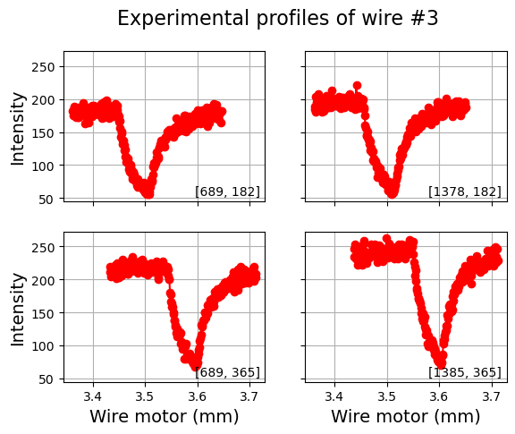

```python
wire_index = 2
calib.plot_exp_wire(wire_index)
```

```
[calib]  file does not exit! (/data/visitor/blc17179/bm32/20260617/PROCESSED_DATA/BaTiO3/BaTiO3_daxmfluo/scan0001/calibration/BaTiO3_daxmfluo_1_notebook_lesscoarse)
[calib] - Clearing calibration log...
In log_append() of generic.py
wdict: [{'material': 'W', 'R': 0.02852506135706538, 'h': 0.7987401572394462, 'p0': 3.418664355571944, 'f1': -0.027131378200820226, 'f2': -0.04185164585032689, 'u1': 1.3067791888094896e-10, 'u2': 9.5460530655801e-08}, {'material': 'W', 'R': 0.029325014797503407, 'h': 0.7028964093152372, 'p0': 3.67030…
[calib] Initial parameters:
[calib] wire\    R         h         p0        f1        f2        u1        u2
[calib]  #1 | 0.028525  0.798740  3.418664  -1.554513  -2.397923  0.000000  0.000005
[calib]  #2 | 0.029325  0.702896  3.670300  -0.207188  3.974421  0.000000  0.000005
[calib]  #3 | 0.027450  0.694278  4.001082  -1.114686  -0.618816  0.000000  0.000005
[calib] - Generating calibration points...
[calib]  > Wire 0:
[calib]    regular 3x3 grid
[calib] Adjusting to avoid EIGER detector bands
[calib]  > Wire 1:
[calib]    regular 3x3 grid
[calib] Adjusting to avoid EIGER detector bands
[calib]  > Wire 2:
[calib]    regular 3x3 grid
[calib] Adjusting to avoid EIGER detector bands
[calib] - Loading experimental intensity profiles...
[calib]    loaded 27 profiles / 8067 data points.
In run_arg ----------generic.py-----
wire: None
var: ['h', 'p0', 'axis', 'R', 'u1', 'u2', 'dm']
bounds: None
self.opt_var: ['h', 'p0', 'f1', 'f2', 'R', 'u1', 'u2', 'dm']
self.opt_bnd: [None, None, None, None, None, None, None, None]
[calib] Calibration of ['h', 'p0', 'axis', 'R', 'u1', 'u2', 'dm'] on wires None...
[calib] - Initializing:
[calib] - preparing sample...
[calib] - preparing data...
[calib] - guessing parameters...
[calib] - setting bounds...
[calib] - objective function...
[calib] - Running...
   Iteration     Total nfev        Cost      Cost reduction    Step norm     Optimality
       0              1         9.7218e+06                                    6.96e+07
       1              2         4.7994e+06      4.92e+06       1.45e+02       4.63e+08
       2              3         3.0509e+06      1.75e+06       1.89e+02       1.34e+08
       3              4         2.6100e+06      4.41e+05       1.25e+02       2.44e+07
```

[output cut: 15 more lines]

```
In log_append() of generic.py
wdict: [{'R': 0.02825594416067127, 'p0': 3.4196871919729293, 'h': 0.7959348170093142, 'f1': -0.027131378111530158, 'f2': -0.04185164575826665, 'u1': 1.3305735580934911e-10, 'u2': 9.545748089409382e-08}, {'R': 0.029220558517323632, 'p0': 3.670184246956136, 'h': 0.7026458280437907, 'f1': -0.0036161041…
[calib] Calibrated parameters:
[calib] optimized (h,p0,f1,f2,R,u1,u2,dm) on wires range(0, 3)
[calib] resulting in fval = 316.02 and GoF = 11.74
[calib] with parameter values and errors as:
[calib] wire\  * R *     * h *     * p0 *    * f1 *    * f2 *    * u1 *    * u2 *
[calib]  #1 | 0.028256  0.795935  3.419687  -1.554513  -2.397923  0.000000  0.000005
[calib]     | 0.000232  0.006379  0.000337  0.001112  0.005951  0.216483  0.014457
[calib]  #2 | 0.029221  0.702646  3.670184  -0.207188  3.974421  0.000000  0.000005
[calib]     | 0.000342  0.006184  0.000633  0.004048  0.022531  0.216483  0.014457
[calib]  #3 | 0.027637  0.692245  4.000085  -1.114686  -0.618816  0.000000  0.000005
[calib]     | 0.000294  0.014057  0.004462  0.008303  0.011576  0.216483  0.014457
[calib] and fitted depth = 0.772988 +- 13432036.566320
[calib] Saving wire parameters to: /data/visitor/blc17179/bm32/20260617/PROCESSED_DATA/BaTiO3/BaTiO3_daxmfluo/scan0001/calibration/BaTiO3_daxmfluo_1_notebook_lesscoarse.calib
```

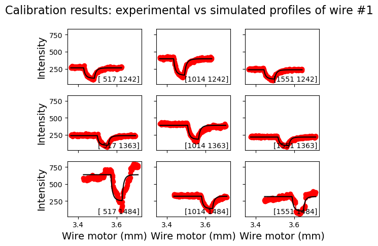

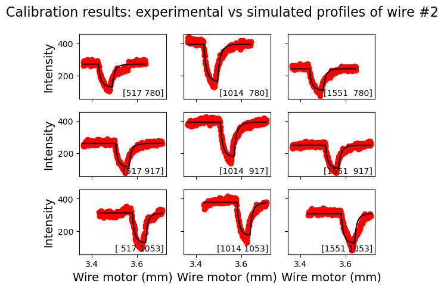

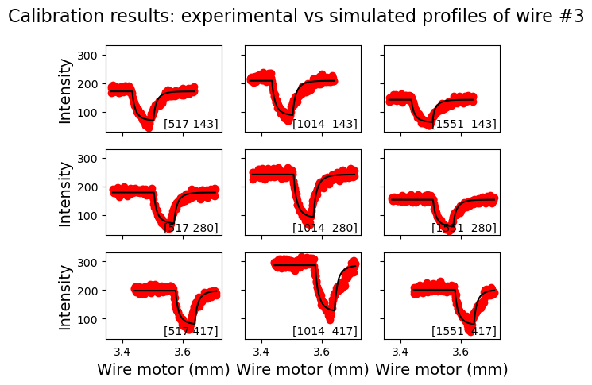

```
[calib]  file does not exit! (/data/visitor/blc17179/bm32/20260617/PROCESSED_DATA/BaTiO3/BaTiO3_daxmfluo/scan0001/calibration/BaTiO3_daxmfluo_1_notebook_lesscoarse)
[calib] - Clearing calibration log...
In log_append() of generic.py
wdict: [{'material': 'W', 'R': 0.02825594416067127, 'h': 0.7959348170093142, 'p0': 3.4196871919729293, 'f1': -0.027131378111530158, 'f2': -0.04185164575826665, 'u1': 1.3305735580934911e-10, 'u2': 9.545748089409382e-08}, {'material': 'W', 'R': 0.029220558517323632, 'h': 0.7026458280437907, 'p0': 3.67…
[calib] Initial parameters:
[calib] wire\    R         h         p0        f1        f2        u1        u2
[calib]  #1 | 0.028256  0.795935  3.419687  -1.554513  -2.397923  0.000000  0.000005
[calib]  #2 | 0.029221  0.702646  3.670184  -0.207188  3.974421  0.000000  0.000005
[calib]  #3 | 0.027637  0.692245  4.000085  -1.114686  -0.618816  0.000000  0.000005
[calib] - Generating calibration points...
[calib]  > Wire 0:
[calib]    regular 6x6 grid
[calib] Adjusting to avoid EIGER detector bands
[calib]  > Wire 1:
[calib]    regular 6x6 grid
[calib] Adjusting to avoid EIGER detector bands
[calib]  > Wire 2:
[calib]    regular 6x6 grid
[calib] Adjusting to avoid EIGER detector bands
[calib] - Loading experimental intensity profiles...
[calib]    loaded 108 profiles / 25426 data points.
[calib] Calibration of ['R', 'h', 'p0', 'axis', 'u1', 'u2', 'dm'] on wires None...
[calib] - Initializing:
[calib] - preparing sample...
[calib] - preparing data...
[calib] - guessing parameters...
[calib] - setting bounds...
[calib] - objective function...
[calib] - Running...
   Iteration     Total nfev        Cost      Cost reduction    Step norm     Optimality
       0              1         1.4825e+08                                    1.48e+09
       1              2         1.1882e+08      2.94e+07       5.59e+02       2.09e+09
       2              3         1.1155e+08      7.27e+06       7.57e+02       6.94e+09
       3              4         1.0605e+08      5.50e+06       2.24e+02       5.59e+10
       4              5         1.0465e+08      1.40e+06       3.16e-05       3.74e+09
`xtol` termination condition is satisfied.
Function evaluations 5, initial cost 1.4825e+08, final cost 1.0465e+08, first-order optimality 3.74e+09.
[calib] - Getting results...
In set_wire(), wire_dict {'R': 0.028143204677073312, 'p0': 3.419773806759772, 'h': 0.7963284655691072, 'f1': -0.02713137811089113, 'f2': -0.04185164575872238, 'u1': 1.3315975914298164e-10, 'u2': 9.545753475605532e-08}
new_dict {'material': 'W', 'R': 0.028143204677073312, 'h': 0.7963284655691072, 'p0': 3.419773806759772, 'f1': -0.02713137811089113, 'f2': -0.04185164575872238, 'u1': 1.3315975914298164e-10, 'u2': 9.545753475605532e-08}
In set_par(), R, f1, f2, u1, u2, h, p0 0.028143204677073312 -0.02713137811089113 -0.04185164575872238 1.3315975914298164e-10 9.545753475605532e-08 0.7963284655691072 3.419773806759772
In set_wire(), wire_dict {'R': 0.029238184093204802, 'p0': 3.670287621694198, 'h': 0.703127673690031, 'f1': -0.003616104104551367, 'f2': 0.06936673103983294, 'u1': 1.3315975914298164e-10, 'u2': 9.545753475605532e-08}
new_dict {'material': 'W', 'R': 0.029238184093204802, 'h': 0.703127673690031, 'p0': 3.670287621694198, 'f1': -0.003616104104551367, 'f2': 0.06936673103983294, 'u1': 1.3315975914298164e-10, 'u2': 9.545753475605532e-08}
In set_par(), R, f1, f2, u1, u2, h, p0 0.029238184093204802 -0.003616104104551367 0.06936673103983294 1.3315975914298164e-10 9.545753475605532e-08 0.703127673690031 3.670287621694198
In set_wire(), wire_dict {'R': 0.027690134552093654, 'p0': 3.9997038389473913, 'h': 0.6917866338898752, 'f1': -0.01945493302186833, 'f2': -0.010800369923899204, 'u1': 1.3315975914298164e-10, 'u2': 9.545753475605532e-08}
new_dict {'material': 'W', 'R': 0.027690134552093654, 'h': 0.6917866338898752, 'p0': 3.9997038389473913, 'f1': -0.01945493302186833, 'f2': -0.010800369923899204, 'u1': 1.3315975914298164e-10, 'u2': 9.545753475605532e-08}
In set_par(), R, f1, f2, u1, u2, h, p0 0.027690134552093654 -0.01945493302186833 -0.010800369923899204 1.3315975914298164e-10 9.545753475605532e-08 0.6917866338898752 3.9997038389473913
In log_append() of generic.py
wdict: [{'R': 0.028143204677073312, 'p0': 3.419773806759772, 'h': 0.7963284655691072, 'f1': -0.02713137811089113, 'f2': -0.04185164575872238, 'u1': 1.3315975914298164e-10, 'u2': 9.545753475605532e-08}, {'R': 0.029238184093204802, 'p0': 3.670287621694198, 'h': 0.703127673690031, 'f1': -0.003616104104…
[calib] Calibrated parameters:
[calib] optimized (R,h,p0,f1,f2,u1,u2,dm) on wires range(0, 3)
[calib] resulting in fval = 4154.08 and GoF = 98.25
[calib] with parameter values and errors as:
[calib] wire\  * R *     * h *     * p0 *    * f1 *    * f2 *    * u1 *    * u2 *
[calib]  #1 | 0.028143  0.796328  3.419774  -1.554513  -2.397923  0.000000  0.000005
[calib]     | 0.000029  0.000732  0.000065  0.000211  0.000772  0.012275  0.002468
[calib]  #2 | 0.029238  0.703128  3.670288  -0.207188  3.974421  0.000000  0.000005
[calib]     | 0.000057  0.000886  0.000099  0.000367  0.002471  0.012275  0.002468
[calib]  #3 | 0.027690  0.691787  3.999704  -1.114686  -0.618816  0.000000  0.000005
[calib]     | 0.000156  0.001033  0.000045  0.003831  0.006399  0.012275  0.002468
[calib] and fitted depth = 0.116442 +- 0.127503
[calib] Saving wire parameters to: /data/visitor/blc17179/bm32/20260617/PROCESSED_DATA/BaTiO3/BaTiO3_daxmfluo/scan0001/calibration/BaTiO3_daxmfluo_1_notebook.calib
```

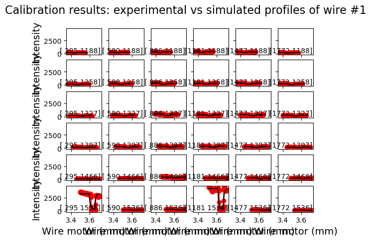

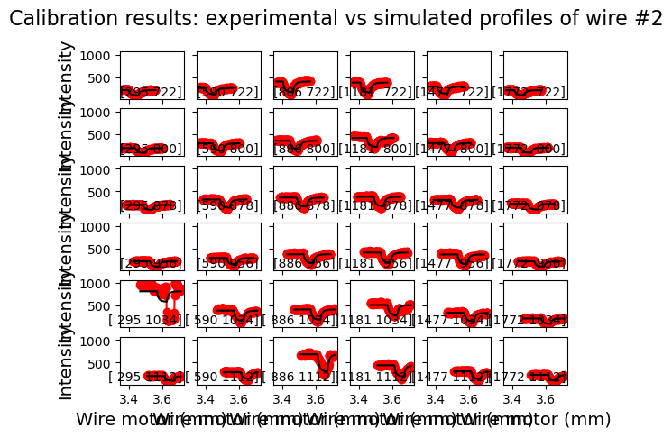

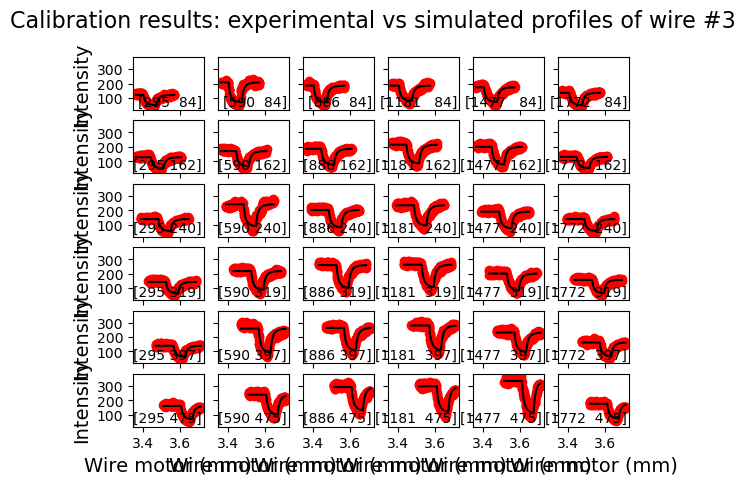

```python
#----------- coarse calibration-----------

#bounds=([-.1,.1],[-.2,.2],[-1,1])  # degrees for axis or f1 f2 u1 u2, and SHOULD be diffeentila value around initial guess
#calib.run(var=['h', 'p0', 'f1'])#, bounds=bounds)
# calib.run(var=['h', 'p0','axis','dm'])
# intermediatecalibfile = ScanID+"_notebook_coarse"
# calib.save_wires(intermediatecalibfile, directory=calib_dir)
# calib.log_plot()
# mplp.show()



# #-------------------------------------------
# calib.load_wires(ScanID+"_notebook_coarse_radii", directory=calib_dir, verbose=3)
# calib.log_restart()



# #calib.load_wires(intermediatecalibfile, directory=calib_dir)
# #calib.set_points_grid(dims=[2, 2], adjust=False)
# calib.run(var=['h', 'p0','R'])

# intermediatecalibfile_1 = ScanID+"_notebook_coarse_radii2"
# calib.save_wires(intermediatecalibfile_1, directory=calib_dir)
# calib.log_plot()
# mplp.show()

# ###---------------------------------------------------------
# #intermediatecalibfile_1 = 'Al_mardisoir_Gedaxm_expo_0.2_nbsteps_400_hmicro1mm_1_notebook_coarse_radii'

# #----------- coarse calibration-----------
# calib.load_wires(intermediatecalibfile_1,directory=calib_dir, verbose=3)
# calib.log_restart()
# calib.set_points_grid(dims=[3, 3], adjust=False)
# calib.run(var=['h', 'p0', 'axis', 'R', 'u2', 'dm'], verbose=3)
# intermediatecalibfile2a = ScanID+"_notebook_lesscoarse"
# calib.save_wires(intermediatecalibfile2a, directory=calib_dir)
# calib.log_plot()
# mplp.show()

#----------- coarse calibration-----------
calib.load_wires(intermediatecalibfile2a,directory=calib_dir, verbose=3)
calib.log_restart()
calib.set_points_grid(dims=[3, 3], adjust=False)
calib.run(var=['h', 'p0', 'axis', 'R', 'u1', 'u2', 'dm'], verbose=3)
intermediatecalibfile2b = ScanID+"_notebook_lesscoarse"
calib.save_wires(intermediatecalibfile2b, directory=calib_dir)
calib.log_plot()
mplp.show()

#----------- fine calibration-----------

calib.load_wires(intermediatecalibfile2b, directory=calib_dir)
calib.log_restart()
calib.data_span = 3.5
calib.set_points_grid(dims=[6, 6],adjust=False)
calib.run(var=['R', 'h', 'p0', 'axis', 'u1', 'u2', 'dm'])
finalcalibfile = ScanID+"_notebook"
calib.save_wires(finalcalibfile, directory=calib_dir)
calib.log_plot()
mplp.show()
```

```python
# calib.log_plot()
# mplp.show()
```

```python
#Al_mardisoir_Gedaxm_expo_0.2_nbsteps_400_hmicro1mm_1_calib
```

```python
calib.load_wires(ScanID+"_notebook", directory=calib_dir)
calib.log_restart()
calib.data_span = 3.5
calib.set_points_grid(dims=[6, 6],adjust=False)
calib.run(var=['R', 'h', 'p0', 'axis', 'u1', 'u2', 'dm'])
finalcalibfile = ScanID+"_notebook_allparams"
calib.save_wires(finalcalibfile, directory=calib_dir)
calib.log_plot()
mplp.show()
```

```python
calib.data_XYcam
```

```
[array([[ 295, 1188],
        [ 590, 1188],
        [ 886, 1188],
        [1181, 1188],
        [1477, 1188],
        [1772, 1188],
        [ 295, 1258],
        [ 590, 1258],
        [ 886, 1258],
        [1181, 1258],
        [1477, 1258],
        [1772, 1258],
        [ 295, 1327],
        [ 590, 1327],
        [ 886, 1327],
        [1181, 1327],
        [1477, 1327],
        [1772, 1327],
        [ 295, 1397],
        [ 590, 1397],
        [ 886, 1397],
        [1181, 1397],
        [1477, 1397],
        [1772, 1397],
        [ 295, 1466],
        [ 590, 1466],
        [ 886, 1466],
        [1181, 1466],
        [1477, 1466],
        [1772, 1466],
        [ 295, 1536],
        [ 590, 1536],
        [ 886, 1536],
        [1181, 1536],
        [1477, 1536],
        [1772, 1536]]),
 array([[ 295,  722],
        [ 590,  722],
        [ 886,  722],
        [1181,  722],
```

[output cut: 53 more lines]

```
        [1181,  319],
        [1477,  319],
        [1772,  319],
        [ 295,  397],
        [ 590,  397],
        [ 886,  397],
        [1181,  397],
        [1477,  397],
        [1772,  397],
        [ 295,  475],
        [ 590,  475],
        [ 886,  475],
        [1181,  475],
        [1477,  475],
        [1772,  475]])]
```

# Test performance

```python
import cProfile
import pstats
import numpy as np

def profile_code():
    # Your code here
    XYcam = np.concatenate(calib.data_XYcam)
    wire = np.concatenate([[i] * len(xy) for i, xy in enumerate(calib.data_XYcam)])
    data_I, data_pw = calib.scan.get_profile_manypixels_centred(wire, XYcam, calib.data_hbs, calib.data_span)

    for i, wid in enumerate(wire):
        calib.data_pw[wid].append(data_pw[i])
        calib.data_I[wid].append(data_I[i])

# Run the profiler
cProfile.runctx('profile_code()', globals(), locals(), 'profile_stats')

# Print the profiling results
stats = pstats.Stats('profile_stats')
stats.strip_dirs().sort_stats('cumtime').print_stats(10)  # Show top 10 time-consuming functions
```

```
Mon Jun 29 10:41:10 2026    profile_stats

         250572 function calls (248743 primitive calls) in 2.553 seconds

   Ordered by: cumulative time
   List reduced from 401 to 10 due to restriction <10>

   ncalls  tottime  percall  cumtime  percall filename:lineno(function)
      2/1    0.000    0.000    2.551    2.551 {built-in method builtins.exec}
      2/1    0.000    0.000    2.551    2.551 <string>:1(<module>)
      2/1    0.000    0.000    2.550    2.550 941033097.py:5(profile_code)
        1    0.005    0.005    2.550    2.550 point.py:1508(get_profile_manypixels_centred)
        1    0.003    0.003    2.522    2.522 point.py:1423(get_profile_manypixels_full)
        1    0.000    0.000    2.518    2.518 pool.py:738(__exit__)
        1    0.000    0.000    2.518    2.518 pool.py:654(terminate)
        1    0.000    0.000    1.530    1.530 pool.py:305(_repopulate_pool)
       64    0.003    0.000    1.519    0.024 process.py:110(start)
       64    0.002    0.000    1.504    0.024 context.py:279(_Popen)
```

```
<pstats.Stats at 0x1503b8a07320>
```